# QUESTION 1 :

Import required libraries and read the provided dataset (youtube_dislike_dataset.csv) and retrieve top5 and bottom 5 records.

```python
import matplotlib.pyplot as plt

import numpy as np
import pandas as pd
```

```python
# reading the dataset

df = pd.read_csv('youtube_dislike_dataset.csv')
```

```python
# retrieve top 5 records

top_5=df.head()
top_5
```

|  | video_id | title | channel_id | channel_title | published_at | view_count | likes | dislikes | comment_count | tags | description | comments |
| --- | --- | --- | --- | --- | --- | --- | --- | --- | --- | --- | --- | --- |
| 0 | --0bCF-iK2E | Jadon Sancho Magical Skills & Goals | UC6UL29enLNe4mqwTfAyeNuw | Bundesliga | 2021-07-01 10:00:00 | 1048888 | 19515 | 226 | 1319 | football soccer ftbol alemn Bundesliga season ... | Enjoy the best skills and goals from Jadon San... | Respect to Dortmund fans,must be sad losing hi... |
| 1 | --14w5SOEUs | Migos - Avalanche (Official Video) | UCGIelM2Dj3zza3xyV3pL3WQ | MigosVEVO | 2021-06-10 16:00:00 | 15352638 | 359277 | 7479 | 18729 | Migos Avalanche Quality Control Music/Motown R... | Watch the the official video for Migos - "Aval... | Migos just makes me want to live my live to th... |
| 2 | --40TEbZ9Is | Supporting Actress in a Comedy: 73rd Emmys | UClBKH8yZRcM4AsRjDVEdjMg | Television Academy | 2021-09-20 01:03:32 | 925281 | 11212 | 401 | 831 |  | Hannah Waddingham wins the Emmy for Supporting... | Hannah's energy bursts through any screen. Wel... |
| 3 | --4tfbSyYDE | JO1'YOUNG (JO1 ver.)' PERFORMANCE VIDEO | UCsmXiDP8S40uBeJYxvyulmA | JO1 | 2021-03-03 10:00:17 | 2641597 | 39131 | 441 | 3745 | PRODUCE101JAPAN JO1 TheSTAR STA... | JO1'YOUNG (JO1 ver.)' PERFORMANCE VIDEO\n\n---... | youngVer>< REN is really PERFECT. It's not ju... |
| 4 | --DKkzWVh-E | Why Retaining Walls Collapse | UCMOqf8ab-42UUQIdVoKwjlQ | Practical Engineering | 2021-12-07 13:00:00 | 715724 | 32887 | 367 | 1067 | retaining wall New Jersey highway Direct Conne... | One of the most important (and innocuous) part... | Keep up with all my projects here: https://pr... |

```python
# retrieve bottom 5 records

bottom_5 = df.tail()
bottom_5
```

|  | video_id | title | channel_id | channel_title | published_at | view_count | likes | dislikes | comment_count | tags | description | comments |
| --- | --- | --- | --- | --- | --- | --- | --- | --- | --- | --- | --- | --- |
| 37417 | zzd4ydafGR0 | Lil Tjay - Calling My Phone (feat. 6LACK) [Off... | UCEB4a5o_6KfjxHwNMnmj54Q | Lil Tjay | 2021-02-12 05:03:49 | 120408275 | 2180780 | 35871 | 81360 | Lil Tjay Steady Calling My Phone Calling My Ph... | Official video for "Calling My Phone" by Lil T... | 'DESTINED 2 WIN' OUT NOW !! https://liltjay.ln... |
| 37418 | zziBybeSAtw | PELICANS at LAKERS \| FULL GAME HIGHLIGHTS \| Ja... | UCWJ2lWNubArHWmf3FIHbfcQ | NBA | 2021-01-16 05:39:05 | 2841917 | 20759 | 1049 | 2624 | NBA G League Basketball game-0022000187 Lakers... | PELICANS at LAKERS \| FULL GAME HIGHLIGHTS \| Ja... | Montrezl Harrell is going crazy with the rebou... |
| 37419 | zzk09ESX7e0 | [MV] (MAMAMOO) - Where Are We Now | UCuhAUMLzJxlP1W7mEk0_6lA | MAMAMOO | 2021-06-02 09:00:10 | 13346678 | 720854 | 4426 | 90616 | MAMAMOO WAW WAW MAMAMOO WAW Where Are We Now... | [MV] (MAMAMOO) - Where Are We Now\n\nInstagra... | I honestly do not know why this song hit so ha... |
| 37420 | zzmQEb0Em5I | FELLIPE ESCUDERO- Master Podcast #12 | UC8NjnNWMsRqq11NYvHAQb1g | Master Podcast | 2020-10-20 20:59:30 | 252057 | 19198 | 1234 | 1471 | master masterpodcast lord lord vinheteiro z z ... | DOCTOR HAIR\nhttps://www.thedoctorhair.com/?fb... | Foi um prazer passar esta tarde com vocs debat... |
| 37421 | zzxPZwaA-8w | Gareth Bale brace secures dramatic comeback on... | UCEg25rdRZXg32iwai6N6l0w | Tottenham Hotspur | 2021-05-23 21:00:31 | 2252090 | 34063 | 868 | 2004 | Spurs Tottenham Hotspur Tottenham Leicester ... | Two minute highlights from Tottenham Hotspur's... | Thank you Kane for everything you have given t... |

# QUESTION 2 :

Check the info of the dataframe and write your inferences on data types and shape of the dataset.

```python
# check the information of the DataFrame

df.info()
```

```
<class 'pandas.core.frame.DataFrame'>
RangeIndex: 37422 entries, 0 to 37421
Data columns (total 12 columns):
 #   Column         Non-Null Count  Dtype
---  ------         --------------  -----
 0   video_id       37422 non-null  object
 1   title          37422 non-null  object
 2   channel_id     37422 non-null  object
 3   channel_title  37422 non-null  object
 4   published_at   37422 non-null  object
 5   view_count     37422 non-null  int64
 6   likes          37422 non-null  int64
 7   dislikes       37422 non-null  int64
 8   comment_count  37422 non-null  int64
 9   tags           37422 non-null  object
 10  description    37422 non-null  object
 11  comments       37264 non-null  object
dtypes: int64(4), object(8)
memory usage: 3.4+ MB
```

```python
# Datatypes of the columns present

df.dtypes
```

```
video_id         object
title            object
channel_id       object
channel_title    object
published_at     object
view_count        int64
likes             int64
dislikes          int64
comment_count     int64
tags             object
description      object
comments         object
dtype: object
```

```python
# Shape of the datframe

df.shape
```

```
(37422, 12)
```

Inferences:

--> The dataset has 37422 rows and 12 columns.

--> OBJECT type columns (count - 8) : 'video_id', 'title', 'channel_id', 'channel_title', 'published_at', 'tags', 'description' & 'comments'.

--> INTEGER(int64) type columns (count - 4) : 'view_count', 'likes', 'dislikes' & 'comment_count'.

--> The dataset has a memory usage of 3.4+ MB, which is relatively larger for a dataset of this size.

--> The 'likes' and 'dislikes' columns are likely the target variables for analysis.

--> These are just some of the inferences that can be made from the data.By analyzing the information in each column, we can gain a deeper understanding of the content of the data and make more informed decisions about how to use them.

# QUESTION 3 :

Check for the Percentage of the missing values and drop or impute them.

```python
# check for missing values
null_values_percentage = (df.isnull().sum()/len(df))*100

null_values_percentage
```

```
video_id         0.000000
title            0.000000
channel_id       0.000000
channel_title    0.000000
published_at     0.000000
view_count       0.000000
likes            0.000000
dislikes         0.000000
comment_count    0.000000
tags             0.000000
description      0.000000
comments         0.422212
dtype: float64
```

```python
# Dropping the null values

df["comments"].fillna("No comments",inplace = True)
```

Here we choose for imputing the null values instead of dropping because the latter leads to loosing the data.

```python
# Rechecking for missing values to assure whether they are removed

df.isnull().sum()
```

```
video_id         0
title            0
channel_id       0
channel_title    0
published_at     0
view_count       0
likes            0
dislikes         0
comment_count    0
tags             0
description      0
comments         0
dtype: int64
```

# QUESTION 4 :

Check the statistical summary of both numerical and categorical columns and write your inferences.

```python
# Checking the statistical summary of numerical columns

df.describe()
```

|  | view_count | likes | dislikes | comment_count |
| --- | --- | --- | --- | --- |
| count | 3.742200e+04 | 3.742200e+04 | 3.742200e+04 | 3.742200e+04 |
| mean | 5.697838e+06 | 1.668147e+05 | 4.989862e+03 | 9.924930e+03 |
| std | 2.426622e+07 | 5.375670e+05 | 3.070824e+04 | 1.171003e+05 |
| min | 2.036800e+04 | 0.000000e+00 | 0.000000e+00 | 0.000000e+00 |
| 25% | 5.122970e+05 | 1.323350e+04 | 2.810000e+02 | 9.000000e+02 |
| 50% | 1.319078e+06 | 4.233050e+04 | 7.960000e+02 | 2.328000e+03 |
| 75% | 3.670231e+06 | 1.304698e+05 | 2.461750e+03 | 6.184000e+03 |
| max | 1.322797e+09 | 3.183768e+07 | 2.397733e+06 | 1.607103e+07 |

INFERENCE :

--> view_count : The mean view count is 5.69 million and the standard deviation is 24.26 million. The minimum view count is 20,368 and the maximum view count is 1.32 billion.

--> likes : This is a continuous variable. The mean count of likes is 166,814 and its standard deviation is 537,567. The minimum number of likes is 0 and the maximum number of likes is 31.84 million.

--> dislikes : The mean number of dislikes is 4,989 and the standard deviation is 30,708. The minimum dislikes is 0 and the maximum count is 2.39 million.

--> comment_count : The mean number of comments is 9,924 and the standard deviation is 117,100. The minimum comments count is 0 and the maximum is 16.07 million.

--> All the numerical datatype variables are now continuous without any null values.

```python
# checking the statistical summary of categorical columns

df.describe(include='object')
```

|  | video_id | title | channel_id | channel_title | published_at | tags | description | comments |
| --- | --- | --- | --- | --- | --- | --- | --- | --- |
| count | 37422 | 37422 | 37422 | 37422 | 37422 | 37422 | 37422 | 37422 |
| unique | 37422 | 37113 | 10961 | 10883 | 36772 | 28799 | 35630 | 37265 |
| top | --0bCF-iK2E | www | UCNAf1k0yIjyGu3k9BwAg3lg | Sky Sports Football | 2020-10-16 04:00:10 |  |  | No comments |
| freq | 1 | 21 | 533 | 533 | 6 | 3817 | 589 | 158 |

INFERENCE :

--> Since these are object datatypes, there will be no mean, minimum & maximum values and quantiles.

--> But there is a new entity called frequency which is the most common value’s frequency

--> There is also another entity called unique which represents the number of unique values present in it.

--> Among all, the less number of unique values is present in 'channel_id' and 'channel_title' which says that the same channels has posted more number of videos

# QUESTION 5 :

Convert datatype of column published_at from object to pandas datetime.

```python
df['published_at'] = pd.to_datetime(df['published_at'])

df['published_at'].dtypes
```

```
dtype('<M8[ns]')
```

The result mean that the datatype of the 'published_at' column is :

datetime64[ns]

# QUESTION 6 :

Create a new column as 'published_month' using the column published_at (display the months only)

```python
df['published_month'] = df['published_at'].dt.month # Creating a new column that extracts only the month from 'publishes_at' column.


df.sample() # Viewing some sample, whether it has been applied
```

|  | video_id | title | channel_id | channel_title | published_at | view_count | likes | dislikes | comment_count | tags | description | comments | published_month |
| --- | --- | --- | --- | --- | --- | --- | --- | --- | --- | --- | --- | --- | --- |
| 17899 | TPGwfTv_b-s | Girls During Wedding \| Indian Weddings \| India... | UCgN55-McINV9y4noG-0QKVg | Paayal Tena Short Videos | 2021-12-06 09:03:00 | 4273382 | 288185 | 5311 | 236 | The paayal jain Bride Bride makeup Salon Mom M... | Full Video on Youtube : The Paayal Jain\nhttps... | Hey Guys Full Video on Youtube : The Paayal Ja... | 12 |

# QUESTION 7 :

Replace the numbers in the column published_month as names of the months i,e., 1 as 'Jan', 2 as 'Feb' and so on.....

```python
months_replacement_dict = {1:'Jan', 2:'Feb', 3:'Mar', 4:'Apr', 5:'May', 6:'Jun', 7:'Jul', 8:'Aug', 9:'Sep', 10:'Oct', 11:'Nov', 12:'Dec'}

df['published_month'].replace(months_replacement_dict, inplace=True)

df.sample()
```

|  | video_id | title | channel_id | channel_title | published_at | view_count | likes | dislikes | comment_count | tags | description | comments | published_month |
| --- | --- | --- | --- | --- | --- | --- | --- | --- | --- | --- | --- | --- | --- |
| 23053 | bEnW-KvHWC4 | I MADE A SPACE COWBOY CAKE + DRESSED UP! | UCDSJCBYqL7VQrlXfhr1RtwA | Les Do Makeup | 2021-06-22 02:01:22 | 698850 | 30013 | 532 | 1397 |  | Shop Savage - http://www.savagex.com/lesliequ... | Lmaoo giddy up ladies we going to space This ... | Jun |

# QUESTION 8 :

Find the number of videos published each month and arrange the months in a decreasing order based on the video count.

```python
videos_count = df['published_month'].value_counts() # Counting videos based on release month

videos_count = videos_count.sort_values(ascending=False) # Arranging in descending order

videos_count
```

```
published_month
Oct    4991
Sep    4880
Nov    4851
Aug    4262
Dec    3072
Jul    2340
Jun    2316
Mar    2258
Feb    2137
Apr    2126
Jan    2108
May    2081
Name: count, dtype: int64
```

# QUESTION 9 :

Find the count of unique video_id, channel_id and channel_title.

```python
# Count of unique video IDs

unique_videos = df['video_id'].nunique()
print("Count of unique video IDs : ",unique_videos)
```

```
Count of unique video IDs :  37422
```

```python
# Count of unique channel IDs

unique_channel_IDs = df['channel_id'].nunique()
print("Count of unique channel IDs : ",unique_channel_IDs )
```

```
Count of unique channel IDs :  10961
```

```python
# Count of unique channel titles

unique_channel_titles = df['channel_title'].nunique()
print("Count of unique channel titles: ", unique_channel_titles)
```

```
Count of unique channel titles:  10883
```

# QUESTION 10 :

Find the top10 channel names having the highest number of videos in the dataset and the bottom10 having lowest number of videos.

```python
# Top 10 channels
top_10_channels = df['channel_title'].value_counts().head(10)
print('Top 10 channels with most number of videos:',top_10_channels, sep ='\n')
```

```
Top 10 channels with most number of videos:
channel_title
Sky Sports Football    533
The United Stand       301
BT Sport               246
NBA                    209
NFL                    162
WWE                    122
SSSniperWolf            99
SSundee                 98
FORMULA 1               87
NHL                     86
Name: count, dtype: int64
```

```python
# Bottom 10 channels
bottom_10_channels = df['channel_title'].value_counts().tail(10)
print('Bottom 10 channels according to count of videos:',bottom_10_channels, sep ='\n')
```

```
Bottom 10 channels according to count of videos:
channel_title
Eiaz                     1
adidas                   1
Universitetet i Agder    1
Team Tapia               1
TheVincentMottola        1
Blocktrainer             1
Movie Addicts            1
1 1 minute mom           1
FLORIN CERCEL            1
Master Podcast           1
Name: count, dtype: int64
```

# QUESTION11 :

Find the title of the video which has the maximum number of likes and the title of the video having minimum likes and write your inferences.

```python
# Title of the video with maximum number of likes

max_likes_title = df.loc[df['likes'].idxmax(), 'title']
print("Title of the video with maximum number of likes :", max_likes_title)
```

```
Title of the video with maximum number of likes : BTS () 'Dynamite' Official MV
```

```python
# Title of the video with minimum number of likes

min_likes_title = df.loc[df['likes'].idxmin(), 'title']
print("Title of the video with minimum number of likes:", min_likes_title)
```

```
Title of the video with minimum number of likes: Kim Kardashian's Must-See Moments on "Saturday Night Live" | E! News
```

INFERENCE :

--> The title of the video with maximum number of likes is "BTS () 'Dynamite' Official MV"

--> The title of the video with minimum number of likes is "Kim Kardashian's Must-See Moments on "Saturday Night Live" | E! News"

# QUESTION 12 :

Find the title of the video which has the maximum number of dislikes and the title of the video having minimum dislikes and write your inferences.

```python
# Title of the video with maximum dislikes

max_dislikes_title = df.loc[df['dislikes'].idxmax(), 'title']
print("Title of the video with maximum dislikes: ", max_dislikes_title)
```

```
Title of the video with maximum dislikes:  Cuties | Official Trailer | Netflix
```

```python
# Title of the video with minimum dislikes

min_dislikes_title = df.loc[df['dislikes'].idxmin(), 'title']
print("Title of the video with minimum dislikes: ", min_dislikes_title)
```

```
Title of the video with minimum dislikes:  Kim Kardashian's Must-See Moments on "Saturday Night Live" | E! News
```

INFERENCE :

--> The title of the video with maximum number of dislikes is "Cuties | Official Trailer | Netflix"

--> The title of the video with minimum number of dislikes is "Kim Kardashian's Must-See Moments on "Saturday Night Live" | E! News"

# QUESTION 13 :

Does the number of views have any effect on how many people disliked the video? Support your answer with a metric and a plot.

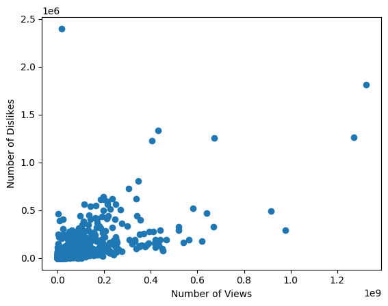

```python
plt.scatter(df['view_count'], df['dislikes']);
plt.xlabel('Number of Views');
plt.ylabel('Number of Dislikes');
```

INFERENCE :

# QUESTION 14 :

Display all the information about the videos that were published in January, and mention the count of videos that were published in January

```python
jan_published_videos = df[df['published_month'] == 'Jan']
jan_published_videos
```

|  | video_id | title | channel_id | channel_title | published_at | view_count | likes | dislikes | comment_count | tags | description | comments | published_month |
| --- | --- | --- | --- | --- | --- | --- | --- | --- | --- | --- | --- | --- | --- |
| 27 | -2Gwm7QfBnE | Q&A With Naisha | UCYwNMbogQFzMccPSuy-pPWg | MianTwins | 2021-01-21 00:05:47 | 872372 | 38626 | 239 | 621 |  | Hey Guys!!! this has been the most requested v... | I feel like Nate and Aishas personality match ... | Jan |
| 48 | -4sfXSHSxzA | SURPRISING BRENT WITH HIS TIKTOK CRUSH!! | UCPpATKqmMV-CNRNWYaDUwiA | Alexa Rivera | 2021-01-16 21:40:04 | 6504784 | 262477 | 5779 | 7907 |  | He had no idea! Thank you guys so much for wat... | Thank you guys for watching and don't forget t... | Jan |
| 95 | -AJD1Fc5rpQ | WE ARE HAVING A BABY! \| finding out i'm pregna... | UCVsTboAhpnuL6j-tDePvNwQ | Tess Christine | 2021-01-03 21:53:48 | 533084 | 38965 | 119 | 1650 |  | I am so happy to tell you that I am pregnant!!... | Okay I needed a moment to collect my thoughts ... | Jan |
| 103 | -AuJiwjsmWk | Do Ugly Foods Taste Worse? Taste Test | UCzpCc5n9hqiVC7HhPwcIKEg | Good Mythical MORE | 2021-01-19 11:00:01 | 1057077 | 22526 | 531 | 773 | gmm good mythical morning rhettandlink rhett a... | Today, we're doing a blind taste test to deter... | "there's nothing wrong with it being bent"\nI ... | Jan |
| 182 | -JhqO2KWr5U | Schlatt gets fit | UCWZp4y1jqBuvLtiyxSs_ZBw | Big guy | 2021-01-24 22:50:57 | 1724965 | 119431 | 325 | 1578 | jschlatt big guy jschlatt highlights schlatt j... | #jschlatt #schlatt #bigguy #short | Schlatt is single handedly wiping out all the ... | Jan |
| ... | ... | ... | ... | ... | ... | ... | ... | ... | ... | ... | ... | ... | ... |
| 37300 | zmzFL5bG-jc | DEVINE MON PERSONNAGE AVANT AKINATOR ! (c'est ... | UCIlr3byh6wmXgcPx_Tm9Ocw | Piwerre | 2021-01-16 16:12:19 | 670357 | 54462 | 832 | 1249 | Piwerre frere de michou crouton among us devin... | Discord Piwerre : https://discord.gg/QBduPgAA... | Mdr michou quand c'est pas ses tournage il fou... | Jan |
| 37329 | zpzjex7qwrA | Lampard Sacked Within Days Rorys Misery \| Chel... | UCkD-ZOixI0a9FjIExDsHsbg | The Kick Off | 2021-01-03 20:13:49 | 428646 | 12060 | 296 | 1505 | Premier league Chelsea chelsea 1-3 Man City Ch... | The Kick Off watched Manchester City destroy C... | True Its like a fighter who Geordie But I thou... | Jan |
| 37345 | zqyv-B6mnBM | Lil Wayne - Ain't Got Time (Audio) | UCO9zJy7HWrIS3ojB4Lr7Yqw | Lil Wayne | 2021-01-21 05:00:10 | 2238244 | 58925 | 2365 | 5539 | lil wayne weezy weezy wednesday wayne carter y... | Official audio for Lil Wayne "Ain't Got Time",... | RIP Juice Wrld, wrote that on two cups, pour o... | Jan |
| 37383 | zwfu1-24T7Q | PRADA Cup Day 1 \| Full Race Replay \| PRADA Cup... | UCo15ZYO_XDRU9LI30OPtxAg | America's Cup | 2021-01-15 04:07:55 | 317382 | 2008 | 83 | 192 | America's Cup Americas Cup AC36 AC75 Presented... | The opening day of the PRADA Cup in Auckland, ... | Incredible how these boats evolve in a short t... | Jan |
| 37418 | zziBybeSAtw | PELICANS at LAKERS \| FULL GAME HIGHLIGHTS \| Ja... | UCWJ2lWNubArHWmf3FIHbfcQ | NBA | 2021-01-16 05:39:05 | 2841917 | 20759 | 1049 | 2624 | NBA G League Basketball game-0022000187 Lakers... | PELICANS at LAKERS \| FULL GAME HIGHLIGHTS \| Ja... | Montrezl Harrell is going crazy with the rebou... | Jan |

2108 rows × 13 columns

```python
jan_video_count = jan_published_videos.shape[0]
print("Number of videos published in January:", jan_video_count)
```

```
Number of videos published in January: 2108
```